# Homework3

Semyon Nikulin

2025-02-13

UT eid: syn228

Github link: https://github.com/SemyonNikulin/HW3.git

# PROBLEM 1

## Claim: Gas stations charge more if they lack direct competition in sight.

Evidence:

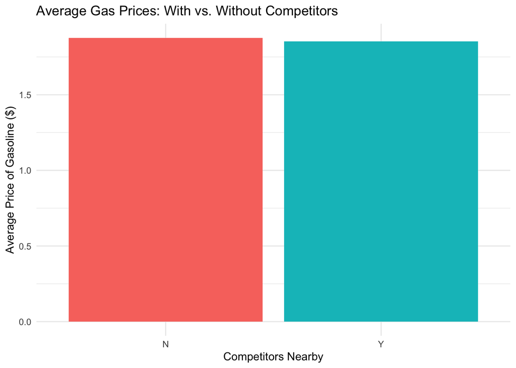

Estimated with a confidence interval of 95%, gas stations without direct competition charge somewhere between -$0.01 and $0.06 more than gas stations with direct competition. However, the p-value for this t.test was 0.15, meaning that his difference is not statistically significant.

Conclusion: This claim is not supported by the data, as our p-value is above 0.05

## Claim: The richer the area, the higher the gas prices.

Evidence:

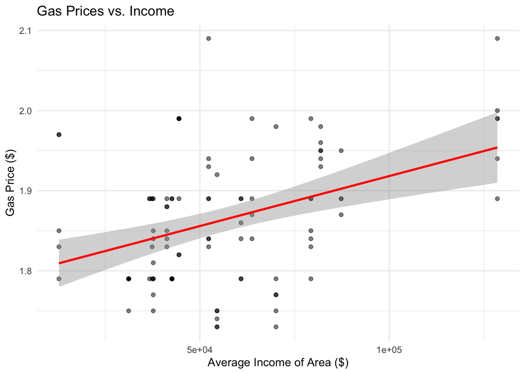

Estimated with a confidence level of 95%, the correlation coefficient between income and gas price is somewhere between 0.22 and 0.55. Additionally, the p-value for this test was 4.12e-5, so our results are statistically significant.

Conclusion: There seems to a moderate, positive correlation between the how rich an area is and the gas prices in that area (the claim is supported by the data)

## Claim: Gas stations at stoplights charge more.

Evidence:

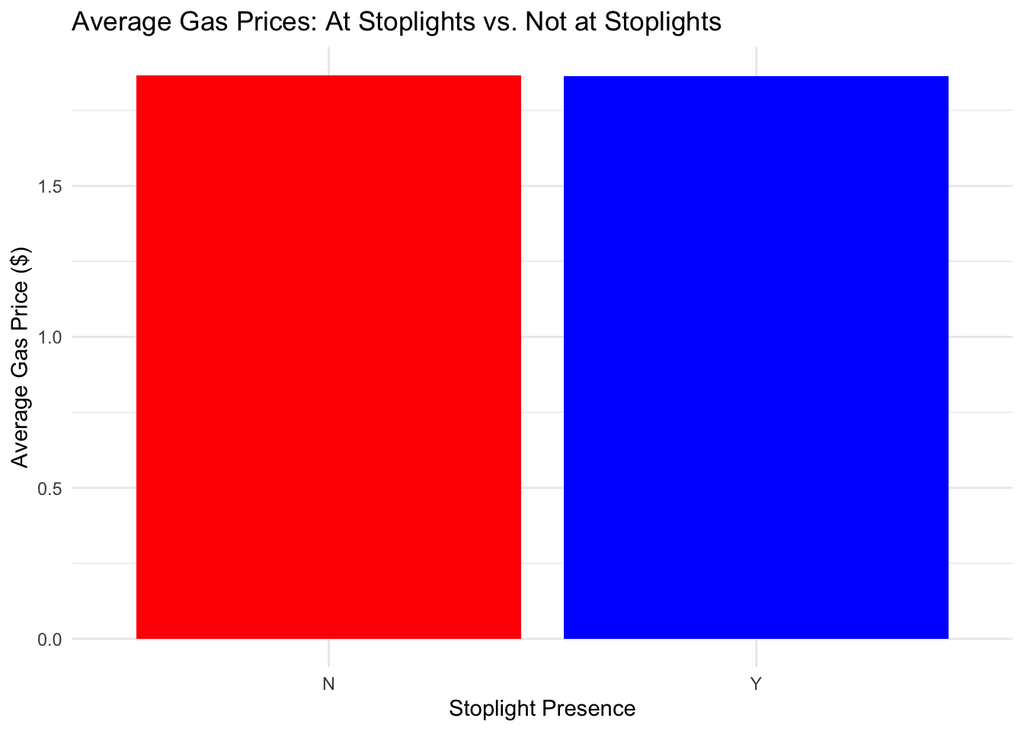

Estimated with a confidence level of 95%, gas stations at stoplights charge somewhere between -$0.04 and $0.03 more than gas stations away from stoplights. However, the p-value for this test was 0.85, so these results are not statistically significant.

Conclusion: Because 0 is in our confidence interval and the p-value is 0.85, this claim is not supported by the data.

## Claim: Gas stations with direct highway access charge more.

Evidence:

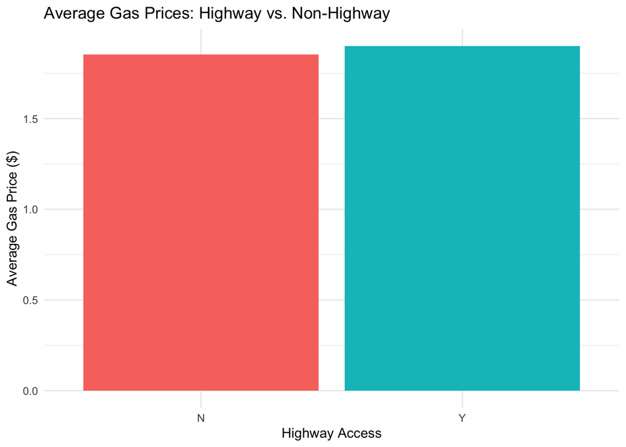

Estimated at a confidence level of 95%, the difference between gas prices at gas stations with highway access and without highway access is somewhere between 0.01 and 0.08. Additionally, the p-value for this test is 0.02, meaning the results are statistically significant.

Conclusion: This claim is supported by the data because 0 is not in the confidence interval and the p-value is less than 0.05.

## Claim: Shell charges more than all other non-Shell brands.

Evidence:

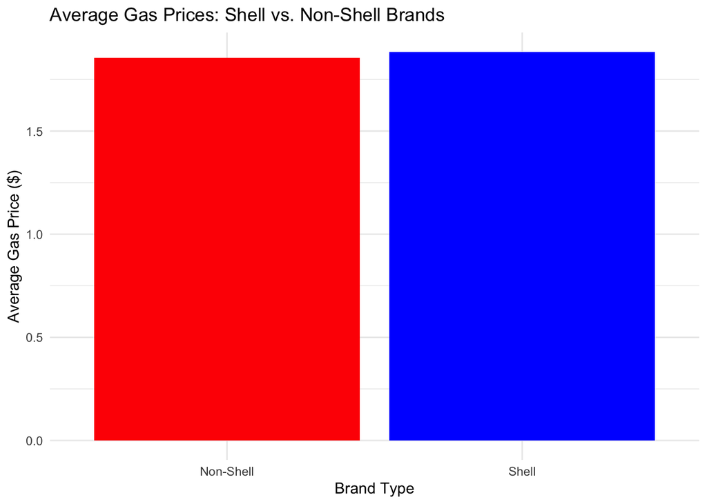

Estimating with a confidence level of 95%, the difference between gas prices of shell brands and non-shell brands is somewhere between -$0.01 and $0.07. However, the p-value for this test is 0.1603 and there 0 is in the confidence interval, so this difference is not statistically significant

Conclusion: This claim is not supported by the data because the p-value is greater than 0.05

# PROBLEM 2

## Part A

```
## Number of Cars: 116
```

```
## 95% Bootstrap Confidence Interval for Average Mileage: 26263.86 - 31784.81 miles
```

## Part B

```
## Number of Cars: 2889
```

```
## 95% Bootstrap Confidence Interval for Proportion of Black Cars: 0.4167532 - 0.453098
```

# PROBLEM 3

## Part A

Question: Consider the shows “Living with Ed” and “My Name is Earl.” Is there evidence that one show consistently produces a higher mean Q1_Happy response among viewers?

Approach: I used a t-test to see if there was a significant difference in happy responses between two shows.

Evidence: Estimated with a confidence level of 95%, the difference in happy responses from the two shows is somewhere between -0.1 and 0.4. The p-value was 0.24

Conclusion: Because 0 is in the confidence interval and the p-value is greater than 0.05, so there is no evidence that one show consistently produces a higher mean Q1_Happy response among viewers.

## Part B

Question: Consider the shows “The Biggest Loser” and “The Apprentice: Los Angeles.” Is there evidence that one show consistently produces a higher mean Q1_Annoyed response among viewers?

Approach: I used a t-test to see if there was a significant difference in annoyed responses between two shows.

Evidence: Estimated with a confidence level of 95%, the difference in annoyed responses from the two shows is somewhere between 0.02 and 0.52. The p-value was 0.04.

Conclusion: Becuase 0 is not in our confidence interval and the p-value is less than 0.05, there is evidence to support that “The Apprentice” produces more annoyed responses.

## Part C

Question: Based on this sample of respondents, what proportion of American TV watchers would we expect to give a response of 4 or greater to the “Q2_Confusing” question?

Approach: I constructed a 95% confidence interval by finding the proportion of confusing responses to total responses and then calculating the margin of error.

Results: I found the 95% confidence interval to be from 0.04 to 0.12, centered at a proportion of 0.08.

Conclusion: I expect 95% of American TV watchers to have a proportion of between 0.04 to 0.12 of answering a 4 or a 5 to the confusion question.

# PROBLEM 4

Question: Does the extra traffic brought to our site from paid search results—above and beyond what we’d see if we “went organic”—justify the cost of the ads themselves?

Approach: I constructed a 95% confidence interval for the difference in the revenue ratio for the treatment and control DMAs by running a Monte Carlo simulation and finding the 0.025th and 0.975th percentiles.

Results: I found the confidence interval of the difference in revenue ratio to be from -0.09 to -0.01. This means that the treatment group had a lower revenue ratio than the control group.

Conclusion: Since 0 is not in my 95% confidence interval, I conclude that there is a significant difference in revenue ratios between the treatment group and the control group. The control group, where advertising on Google AdWords continued, had a statistically higher revenue ratio than the treatment group, which paused Google AdWords.